# Mushroom Classification - *Is it Poisonous?*

## Dataset:

The dataset I used for this project is a well-known mushroom database that provides many attributes of different mushroom species.

My goal for this project was to build a model that could most accurately predict whether a mushroom is edible or poisonous, based on the factors in the dataset. There are a number of factors that contribute to figuring out if a mushroom is poisonous or not, so I wanted each field to contribute equal weight to the model.

My motivation for choosing this dataset was the amount of columns of different measurments and factors. I think this will be very helpful in increasing the accuracy of my final model. I have also always wanted to be able to identify mushrooms that are poisonous or not so this was exciting for me.

In total there are 22 attribute columns in this dataset. Each variable is related to different physical or ecological trait of the mushrooms:

- Cap shape, color, and surface texture
- Gill attachment, spacing, size, and color
- Stalk shape and color, both above and below the 'ring'

These three categories are important visual identifiers of a mushroom's edibility - certain colors or patterns on a mushroom's cap can indicate certain death if consumed. These are useful for my model to identify these patterns.

- Veil type and color
- Ring number and type
- Spore print color

These two are also specific to certain species, and are good indicators for edibility.

- Populaiton
- Habitat

Habitat and population provide ecological context that narrows down species possibilities. Knowing if a mushroom grows on wood, soil, dung, or specific tree species reveals its ecological role and helps distinguish it from toxic look-alikes.

- Bruises or not
- Odor

```python
# --- Setup & Student Configuration ---
import numpy as np
import pandas as pd
import scipy,sklearn
import matplotlib.pyplot as plt
import seaborn as sns

from sklearn.model_selection import train_test_split
from sklearn.compose import ColumnTransformer
from sklearn.pipeline import Pipeline
from sklearn.preprocessing import OneHotEncoder, StandardScaler
from sklearn.impute import SimpleImputer
from sklearn.decomposition import PCA
from sklearn.cluster import KMeans
from sklearn.base import clone


from sklearn.ensemble import RandomForestClassifier, RandomForestRegressor
from sklearn.metrics import accuracy_score, mean_squared_error, r2_score

RANDOM_SEED = 42
np.random.seed(RANDOM_SEED)
```

```python
# Helpful for grading
print("pandas:",pd.__version__)
print("scipy:",scipy.__version__)
print("sklearn:",sklearn.__version__)
print("numpy:",np.__version__)
```

```
pandas: 2.3.3
scipy: 1.16.3
sklearn: 1.8.0
numpy: 1.26.4
```

## Task 1 — Load + Preprocess + Split (Combined)

Implement `load_preprocess_split(...)`.

- Loads dataset
- Pre-processes features as necessary for model.
- Splits into train/test using an 80/20 split
- Returns X_train, X_test, y_train, y_test

Checks for number of points, number of features, and splits

```python
from typing import Dict, Tuple, Any
import numpy as np
import pandas as pd
from sklearn.preprocessing import OneHotEncoder
from sklearn.model_selection import train_test_split

def load_preprocess_split():
    data = pd.read_csv('mushroom_csv.csv')
    data.dropna(axis=1, inplace=True) #stalk-root column has 2000 NA values

    # 'class' column is the output
    X = data.drop(columns=['class', 'veil-type']) # veil-type column has no variance
    y = data['class']

    # columns are strings
    encoder = OneHotEncoder(sparse_output=False, handle_unknown='ignore')

    X_encoded = encoder.fit_transform(X)
    column_names = encoder.get_feature_names_out(X.columns) # Get nice column names back
    X_final = pd.DataFrame(X_encoded, columns=column_names)

    # Split
    X_train, X_test, y_train, y_test = train_test_split(X_final, y, test_size=0.2, random_state=42)
    return X_train, X_test, y_train, y_test
```

```python
X_train, X_test, y_train, y_test = load_preprocess_split()
print("X_train shape:", X_train.shape, "shape")
print("X_test shape:", X_test.shape, "shape")
print("y_train shape:", y_train.shape, "y_test shape:", y_test.shape)
```

```
X_train shape: (6499, 111) shape
X_test shape: (1625, 111) shape
y_train shape: (6499,) y_test shape: (1625,)
```

## Task 2 Unsupervised Learning: PCA + K-means + Plot

- Compute the first 2 components of a **PCA** for visualization in fit_pca_for_plot().
- Fit **KMeans(k=K_CLUSTERS)** on dataset in fit_kmeans().
- Produce a two scatter plots with PCA values

```python
def fit_pca_for_plot(X_train, X_test, random_seed: int = 42):

    """Returns 2D PCA embeddings for train/test."""
    # Standardize
    scaler = StandardScaler()
    X_train_scaled = scaler.fit_transform(X_train)
    X_test_scaled = scaler.transform(X_test)

    # PCA
    pca = PCA(n_components=2, random_state=random_seed)
    X_train_2d = pca.fit_transform((X_train_scaled - X_train_scaled.mean(axis=0)) / (X_train_scaled.std(axis=0)))
    X_test_2d = pca.transform(X_test_scaled)

    var_ratio = pca.explained_variance_ratio_
    print(f"PC1 explains {var_ratio[0]:.2%} of variance")
    print(f"PC2 explains {var_ratio[1]:.2%} of variance")
    print(f"Total info captured in 2D: {sum(var_ratio):.2%}")

    return X_train_2d, X_test_2d


def fit_kmeans(X_train,k=5):
    km = KMeans(n_clusters=k, n_init=10)
    clusters = km.fit_predict(X_train)
    return clusters


def plot_clusters_with_target(X_2d: np.ndarray, clusters: np.ndarray, y: pd.Series):
    """Scatter plot: color by cluster, highlight by target."""
    fig, (ax1, ax2) = plt.subplots(1, 2, figsize=(16, 8))

    # Colored by clusters
    sns.scatterplot(x=X_2d[:, 0], y=X_2d[:, 1], hue=clusters, palette='brg', ax=ax1)
    ax1.set_title(f'K-Means Clustering (k={len(np.unique(clusters))})')
    ax1.set_xlabel('PCA Component 1')
    ax1.set_ylabel('PCA Component 2')

    # Colored by target (edible/poisonous)
    sns.scatterplot(x=X_2d[:, 0], y=X_2d[:, 1], hue=y, palette='Set1', ax=ax2)
    ax2.set_title('Edible vs Poisonous Clusters')
    ax2.set_xlabel('PCA Component 1')
    ax2.set_ylabel('PCA Component 2')

    plt.tight_layout()
    plt.show()
```

```
PC1 explains 9.02% of variance
PC2 explains 7.63% of variance
Total info captured in 2D: 16.65%
```

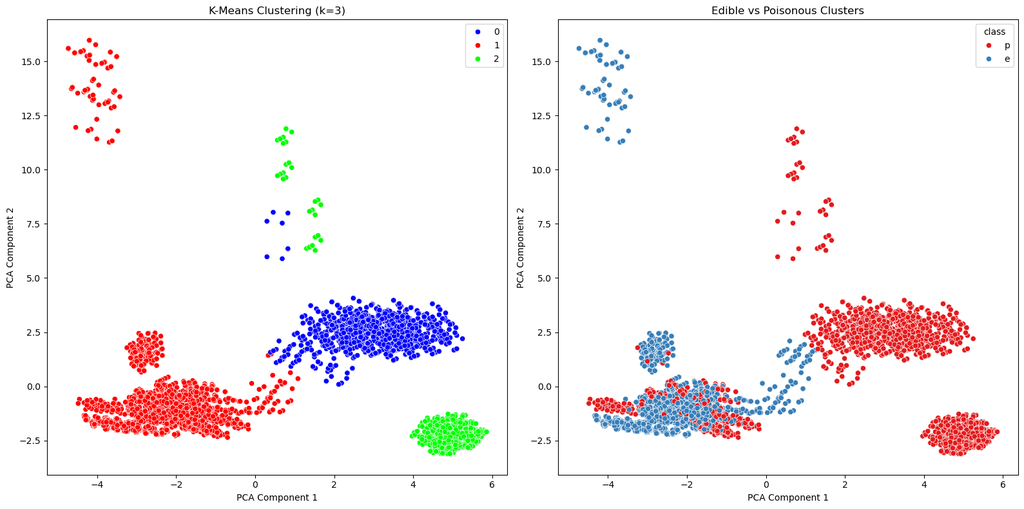

```python
X_train_2d, X_test_2d = fit_pca_for_plot(X_train, X_test)
train_clusters = fit_kmeans(X_train, k=3)
plot_clusters_with_target(X_train_2d, train_clusters, y_train)
```

## Unsupervised Questions

# Task 3 - Train Model

1. Select a model that matches my goal, and explain why it is a good fit.
2. Implement
   - Implement that model in build_model
   - Write an evaluation function that is appropriate for model and task.
   - train and evaluate the model in train_eval()
3. Describe how these results helps solve my goal.

### Model Justification

For this dataset, the goal is to not die from eating a poisonous mushroom. To do this in the most accurate way possible, the model I chose is Random Forest Classifier. Random Forest is the best option because it handles categorical data well, and it can tell me exactly which features (like "odor" or "gill color") are the biggest red flags for poison. Also, mushroom traits don't always follow a straight line, and Random Forest can capture complex "if-this-then-that" rules better than simpler models.

# Implementation

```python
from sklearn import tree
from sklearn.metrics import r2_score
from sklearn.ensemble import RandomForestClassifier
from sklearn.metrics import ConfusionMatrixDisplay, confusion_matrix, classification_report, accuracy_score, precision_score, recall_score, f1_score
import matplotlib.pyplot as plt
import pandas as pd

def build_model(n_estimators=100, max_depth=None):
    """Initializes a Random Forest Classifier."""
    model = RandomForestClassifier(n_estimators=n_estimators, max_depth=max_depth, random_state=42)

    return model

def evaluate_predictions(y_true, y_pred) -> dict:
    # pos_label = 'p' for poisonous
    metrics = {
        "accuracy": accuracy_score(y_true, y_pred),
        "precision": precision_score(y_true, y_pred, pos_label='p'),
        "recall": recall_score(y_true, y_pred, pos_label='p'),
        "f1_score": f1_score(y_true, y_pred, pos_label='p')
        }

    return metrics

def train_eval(X_train, X_test, y_train, y_test):
    # Build and train model
    model = build_model()
    model.fit(X_train, y_train)

    # Predict + evaluate
    y_pred = model.predict(X_test)
    metrics = evaluate_predictions(y_test, y_pred)

    # Visualizations
    #confusion matrix
    ConfusionMatrixDisplay.from_predictions(y_test, y_pred, cmap='OrRd')
    plt.title("Confusion Matrix: Edible vs Poisonous")
    plt.show()

    #feature importance
    importances = pd.Series(model.feature_importances_, index=X_train.columns)
    importances.nlargest(10).plot(kind='barh').invert_yaxis()
    plt.title("10 Best Diagnostic Features")
    plt.show()

    return model, metrics
```

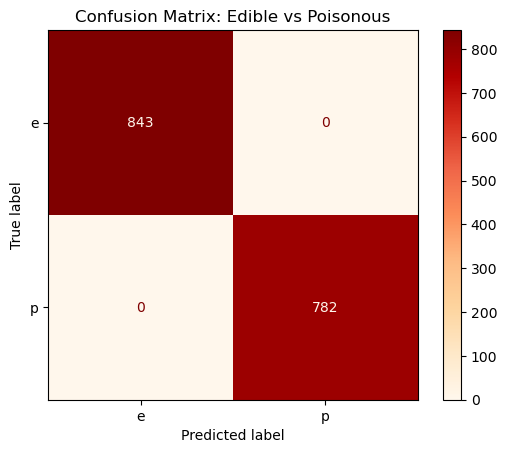

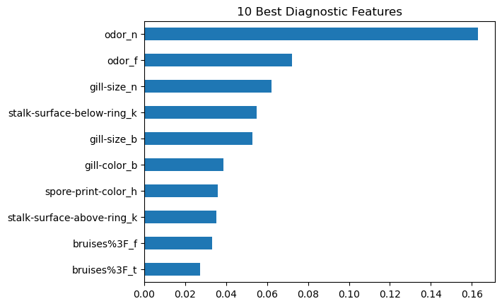

```
(RandomForestClassifier(random_state=42),
 {'accuracy': 1.0, 'precision': 1.0, 'recall': 1.0, 'f1_score': 1.0})
```

```python
results = train_eval(
    X_train, X_test, y_train, y_test
)
results
```

# Results (20 points)

The last plot shows the top 10 features that are used to determine whether a mushroom is edible or not. Odor 'n', meaning none is a good predictor of an edible mushroom, and 'f', meaning foul is a good predictor of a poisonous mushroom. The next few are gill size (broad 'b' or narrow 'n'), and buff ('b') gill color. This is just a good visualization to see which features the model is using to distinguish between poisonous and edible mushrooms.

First, to evaluate the quality of my model, we can look at the returned dictionary where the 'recall' score for 'p' tells you exactly what percentage of poisonous mushrooms were correctly identified. The other metrics it returns are 'accuracy', 'precision', and 'f1_score', which is used to measure the balance of precision and recall. For each of these I would be looking for a score of 1.0 which is 100%, which is exactly what I got. This means that my model is 100% accurate! However, though these metrics are very good, this mushroom dataset is famously very good for providing perfect classifications. The features provided are so consistent that a random forest can use these features to return results with 'perfect' accuracy.

The next plot is a confusion matrix showing the number of mushrooms that were either correctly identified as edible/poisonous, and the number that were incorrectly identified as edible/poisonous. Since my dataset requires classification (categorical data) rather than regression (numerical data), a scatter plot would just show dots on top of each other at the (0,0) and (1,1) positions. That is why I chose to use a confusion matrix to evaluate the results. The bottom-left square on the matrix represents false-negative predictions (poisonous mushrooms that were labeled as edible), since this quare shows a 0, that means my model has not misclassified any of the mushrooms that could kill you!